# Figure 4(b.1): Stata to R

Bindler and Hjalmarsson (2021), *The Impact of the First Professional Police Forces on Crime*, JEEA 19(6)

This document translates the Stata code behind Figure 4, panel (b.1) “Robbery, Treated”, into R. Each R chunk starts with the original Stata lines as comments, labelled with their line numbers in `ab_rh_police_and_crime_jeea_data/ab_rh_police_and_crime_jeea.do`. The figure comes from the `figure4` block (lines 334-524); the DD estimate printed on the figure comes from the `table3` block (lines 717-773). Lines that only build the other outcomes (burglary, homicide) or the uncertain-area panel (b.2) are left out.

Render from the project folder with `quarto render figure4b1.qmd`.

```r
library(haven)     # read Stata .dta files
library(dplyr)
library(tidyr)
library(ggplot2)
library(sandwich)  # robust covariance, as in Stata's `, r` option
```

## 1. Load the data and define the areas

`gen x = (condition)` creates a 0/1 indicator. `replace ... if` overwrites values row by row, so later lines win: an uncertain observation first gets area 2, then area 3.

```r
# Stata (l. 338-348):
#   use ab_rh_police_and_crime_jeea_london_main1.dta, clear
#   gen treat = (dist_mls<=4 & city==0)
#   gen uncertain = (dist_mls<=7 & city==0 & treat==0)
#   gen area = .
#     replace area = 1 if city==1
#     replace area = 2 if treat==0 & city==0
#     replace area = 3 if uncertain==1
#     replace area = 4 if treat==1
#     label define area 1 "city" 2 "control" 3 "uncertain" 4 "treatment" 5 "overall"
#     label values area area
trials <- read_dta(
  "ab_rh_police_and_crime_jeea_data/ab_rh_police_and_crime_jeea_london_main1.dta"
) |>
  mutate(
    treat     = as.integer(dist_mls <= 4 & city == 0),
    uncertain = as.integer(dist_mls <= 7 & city == 0 & treat == 0),
    area = case_when(
      city == 1      ~ 1L,  # city: City of London
      treat == 1     ~ 4L,  # treatment: within 4 miles of Charing Cross
      uncertain == 1 ~ 3L,  # uncertain: 4-7 miles
      TRUE           ~ 2L   # control: beyond 7 miles
    )
  )
```

## 2. Build the monthly panel

Each row of the data is one trial. `gen crimes = 1` followed by `collapse (sum) crimes, by(...)` counts trials per group, like `count()`. `treat` and `uncertain` are fixed by `area`, so grouping by `area` is enough. `fillin` adds every missing combination of the listed variables, and the next line sets the count to 0 there, like `complete()`. `reshape wide` then puts each offence in its own column; panel (b.1) only needs robbery, so the robbery rows are kept instead.

```r
# Stata (l. 350-371):
#   gen crimes = 1
#   collapse (sum) crimes, by(year month area treat uncertain offsubcat_comb)
#   fillin year month area offsubcat_comb
#   replace crimes=0 if _fillin==1 & crimes==.
#   drop _fillin
#   replace treat=1 if area==4 & treat==.
#   replace treat=0 if area!=4 & treat==.
#   replace uncertain=1 if area==3 & uncertain==.
#   replace uncertain=0 if area!=3 & uncertain==.
#   reshape wide crimes, i(year month area treat uncertain) j(offsubcat_comb) string
#   rename crimesrobbery_combined robbery
panel <- trials |>
  count(year, month, area, offsubcat_comb, name = "crimes") |>
  complete(year, month, area, offsubcat_comb, fill = list(crimes = 0L)) |>
  filter(offsubcat_comb == "robbery_combined") |>
  transmute(year, month, area,
            treat     = as.integer(area == 4),
            uncertain = as.integer(area == 3),
            robbery   = crimes)

stopifnot(nrow(panel) == 17 * 12 * 4)  # 1821-1837 x 12 months x 4 areas
```

## 3. Post-reform indicator and event-year bins

`ym(year, month)` and `tm(1821m1)` are Stata monthly dates. Each `event` bin is a September-August year, because the Met started in September 1829. Bin 9 (September 1828 to August 1829) is the last pre-reform year and becomes the omitted category. The 17 `replace` lines reduce to one formula.

```r
# Stata (l. 383-411):
#   gen post1829 = 0
#   replace post1829 = 1 if year>=1830
#   replace post1829 = 1 if year==1829 & month>=9
#   gen date = ym(year,month)
#   format date %tm
#   gen event = .
#     replace event = 1 if date>=tm(1821m1) & date<=tm(1821m8)
#     replace event = 2 if date>=tm(1821m9) & date<=tm(1822m8)
#     ...
#     replace event = 9 if date>=tm(1828m9) & date<=tm(1829m8)
#     replace event = 10 if date>=tm(1829m9) & date<=tm(1830m8)
#     ...
#     replace event = 16 if date>=tm(1835m9) & date<=tm(1836m8)
#     replace event = 17 if date>=tm(1836m9)
panel <- panel |>
  mutate(
    post1829 = as.integer(year >= 1830 | (year == 1829 & month >= 9)),
    # A new bin starts each September; bin 17 runs to the end of the sample.
    event = as.integer(pmin(year - 1820 + (month >= 9), 17))
  )

# Check the bins against the Stata date ranges.
panel |>
  mutate(ym = sprintf("%d-%02d", year, month)) |>
  group_by(event) |>
  summarise(from = min(ym), to = max(ym))
```

```
# A tibble: 17 × 3
   event from    to
   <int> <chr>   <chr>
 1     1 1821-01 1821-08
 2     2 1821-09 1822-08
 3     3 1822-09 1823-08
 4     4 1823-09 1824-08
 5     5 1824-09 1825-08
 6     6 1825-09 1826-08
 7     7 1826-09 1827-08
 8     8 1827-09 1828-08
 9     9 1828-09 1829-08
10    10 1829-09 1830-08
11    11 1830-09 1831-08
12    12 1831-09 1832-08
13    13 1832-09 1833-08
14    14 1833-09 1834-08
15    15 1834-09 1835-08
16    16 1835-09 1836-08
17    17 1836-09 1837-12
```

## 4. Event-study regression

`1.event#1.treat` is a dummy equal to 1 when `event == 1` and `treat == 1`. Bin 9 is left out, so every coefficient is relative to September 1828 to August 1829. `i.year i.month i.area` add year, calendar-month and area fixed effects. The `, r` option gives heteroskedasticity-robust (HC1) standard errors.

```r
# Stata (l. 414-428), with y = robbery:
#   foreach y in burglary robbery homicide{
#   reg `y' 1.event#1.treat 2.event#1.treat 3.event#1.treat 4.event#1.treat ///
#       5.event#1.treat 6.event#1.treat 7.event#1.treat 8.event#1.treat ///
#       10.event#1.treat 11.event#1.treat 12.event#1.treat 13.event#1.treat ///
#       14.event#1.treat 15.event#1.treat 16.event#1.treat 17.event#1.treat ///
#       1.event#1.uncertain 2.event#1.uncertain ... 8.event#1.uncertain ///
#       10.event#1.uncertain ... 17.event#1.uncertain ///
#       i.year i.month i.area, r
bins <- setdiff(1:17, 9)
for (b in bins) {
  panel[[paste0("treat_ev", b)]]     <- panel$treat     * (panel$event == b)
  panel[[paste0("uncertain_ev", b)]] <- panel$uncertain * (panel$event == b)
}
es_terms <- c(paste0("treat_ev", bins), paste0("uncertain_ev", bins))

es_fit <- lm(
  reformulate(c(es_terms, "factor(year)", "factor(month)", "factor(area)"),
              response = "robbery"),
  data = panel
)
```

## 5. Coefficients and confidence intervals

`parmest` saves the coefficient table with confidence intervals: estimate ± t(0.975, residual df) × robust s.e. The two `keep if` lines drop the zero rows Stata reports for base levels, which `lm()` does not report. The first 16 remaining rows are the treated interactions. The `t` lines map bin `b` to `b - 9`, so the omitted year is 0 and the first post-reform year is 1. The `expand` lines add a `t = 0` row of zeros; in the plot it only anchors the dashed DD line at 0, which step 7 draws directly. The 90% intervals are never plotted, so they are skipped.

```r
# Stata (l. 429-457):
#   parmest, level(90 95) saving(esd_`y', replace)
#   use esd_`y', clear
#   keep parm estimate min95 max95 min90 max90
#   keep if min95!=0 & max95!=0
#   keep if min90!=0 & max90!=0
#   rename estimate coef
#   gen id = "."
#   replace id = "treatment" if _n>=1 & _n<=16
#   replace id = "uncertain" if _n>=17 & _n<=32
#   drop if id=="."
#   bys id: gen t = _n
#   replace t = t-8
#   replace t = t-1 if t<=0
#   expand 2 if t==-1, gen(flag)
#   replace t = 0 if flag==1
#   replace coef = 0 if flag==1
#   replace min95 = 0 if flag==1
#   replace max95 = 0 if flag==1
#   ...
#   sort id t
robust_ci <- function(fit) {
  b    <- coef(fit)
  se   <- sqrt(diag(vcovHC(fit, type = "HC1")))
  crit <- qt(0.975, df.residual(fit))
  tibble(term = names(b), coef = b, se = se,
         min95 = b - crit * se, max95 = b + crit * se)
}

es_coefs <- robust_ci(es_fit) |>
  filter(term %in% paste0("treat_ev", bins)) |>
  mutate(t = as.integer(sub("treat_ev", "", term)) - 9L,
         period = if_else(t < 0, "pre", "post"))
es_coefs
```

```
# A tibble: 16 × 7
   term         coef    se  min95    max95     t period
   <chr>       <dbl> <dbl>  <dbl>    <dbl> <int> <chr>
 1 treat_ev1   0.362 0.816 -1.24   1.96       -8 pre
 2 treat_ev2   0.908 0.740 -0.544  2.36       -7 pre
 3 treat_ev3  -0.623 0.649 -1.90   0.651      -6 pre
 4 treat_ev4  -0.891 0.607 -2.08   0.301      -5 pre
 5 treat_ev5  -0.378 0.639 -1.63   0.876      -4 pre
 6 treat_ev6   1.23  0.723 -0.189  2.65       -3 pre
 7 treat_ev7   0.274 0.829 -1.35   1.90       -2 pre
 8 treat_ev8   1.15  0.743 -0.305  2.61       -1 pre
 9 treat_ev10 -1.15  0.528 -2.19  -0.116       1 post
10 treat_ev11 -0.798 0.556 -1.89   0.293       2 post
11 treat_ev12 -0.785 0.605 -1.97   0.402       3 post
12 treat_ev13 -0.535 0.559 -1.63   0.563       4 post
13 treat_ev14 -0.604 0.635 -1.85   0.644       5 post
14 treat_ev15 -1.18  0.603 -2.36   0.00466     6 post
15 treat_ev16 -1.14  0.635 -2.39   0.106       7 post
16 treat_ev17 -0.435 0.655 -1.72   0.850       8 post
```

## 6. DD estimate for the label

The do-file types the DD numbers in by hand: -1.032 with s.e. 0.129. They belong to Table 3, panel B, column (1), where the published s.e. is 0.219; 0.129 is the uncertain-area coefficient in the same column. Here the Table 3 regression is estimated, and the label uses the computed values.

```r
# Stata, table3 block (l. 764-773), with y = robbery:
#   gen post1829 = 0
#   replace post1829 = 1 if year>=1830
#   replace post1829 = 1 if year==1829 & month>=9
#   reg `y' 1.treat#1.post1829 1.uncertain#1.post1829 ///
#       i.year i.month i.area, r
# Hard-coded label values in the figure4 block (l. 466-471):
#   if temp == "robbery"{
#     local ddc_t = -1.032
#     local dds_t = 0.129
#     ...
#   }
dd_fit <- lm(robbery ~ treat:post1829 + uncertain:post1829 +
               factor(year) + factor(month) + factor(area),
             data = panel)
dd <- robust_ci(dd_fit) |> filter(term == "treat:post1829")
dd
```

```
# A tibble: 1 × 5
  term            coef    se min95  max95
  <chr>          <dbl> <dbl> <dbl>  <dbl>
1 treat:post1829 -1.03 0.219 -1.46 -0.603
```

```r
# Table 3, panel B, column (1): -1.032 (0.219)
stopifnot(abs(dd$coef - (-1.032)) < 5e-4, abs(dd$se - 0.219) < 5e-4)
```

## 7. Plot

`connected` draws points joined by a line. Pre- and post-reform points are separate series, so the line breaks at the omitted year. `msymbol(Oh)` is a hollow circle and `msymbol(O)` a filled one. `gs0`, `gs5` and `gs10` are Stata grey levels, from black to light grey. `placement(w)` puts the text box to the left of the point (-1, 5.5).

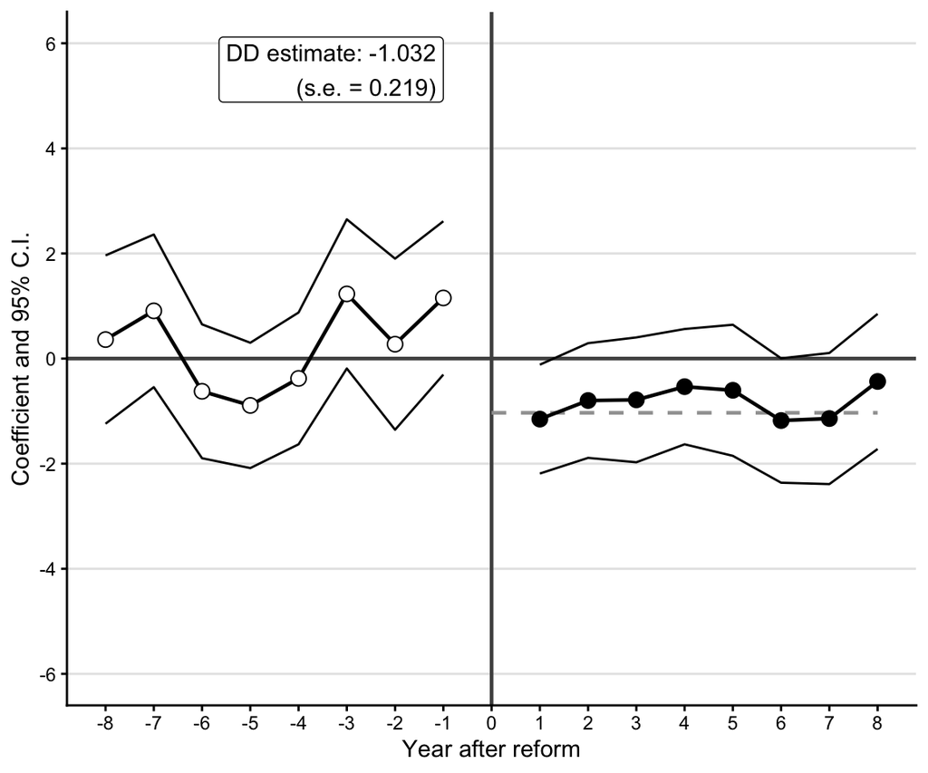

Figure 4(b.1): Robbery, Treated.

```r
# Stata (l. 479-498):
#   gen ddc = `ddc_t' if id=="treatment"
#   twoway ///
#   (connected coef t if t<0 & id=="treatment", msymbol(Oh) mcolor(gs0) msize(large) lw(medthick) lc(gs0)) ///
#   (connected coef t if t>0 & id=="treatment", msymbol(O) mcolor(gs0)  msize(large) lw(medthick) lc(gs0)) ///
#   (line min95 t if t<0 & id=="treatment", lcolor(gs0) lw(med) lp(solid)) ///
#   (line min95 t if t>0 & id=="treatment", lcolor(gs0) lw(med) lp(solid)) ///
#   (line max95 t if t<0 & id=="treatment", lcolor(gs0) lw(med) lp(solid)) ///
#   (line max95 t if t>0 & id=="treatment", lcolor(gs0) lw(med) lp(solid)) ///
#   (line ddc t if t>=0 & id=="treatment", lc(gs10) lp(dash) lw(medthick)), ///
#   xline(0, lc(gs5) lw(medthick)) ///
#   yline(0, lc(gs5) lw(medthick)) ///
#   xlabel(-8(1)8) ///
#   ylabel(-6(2)6) ///
#   text(5.5 -1 "DD estimate: `ddc_t'" "(s.e. = `dds_t')", ///
#   size(medium) placement(w) box fc(white)) ///
#   ytitle("Coefficient and 95% C.I.") xtitle("Year after reform") ///
#   graphregion(color(white)) bgcolor(white) legend(off)
#   graph export "figure4_`y'_1.pdf", replace
fig4b1 <- ggplot(es_coefs, aes(t, coef, group = period)) +
  geom_vline(xintercept = 0, colour = "grey31", linewidth = 0.8) +
  geom_hline(yintercept = 0, colour = "grey31", linewidth = 0.8) +
  annotate("segment", x = 0, xend = 8, y = dd$coef, yend = dd$coef,
           colour = "grey63", linetype = "dashed", linewidth = 0.8) +
  geom_line(aes(y = min95), linewidth = 0.5) +
  geom_line(aes(y = max95), linewidth = 0.5) +
  geom_line(linewidth = 0.8) +
  geom_point(aes(shape = period), size = 3, fill = "white") +
  scale_shape_manual(values = c(pre = 21, post = 19), guide = "none") +
  annotate("label", x = -1, y = 5.5, hjust = 1,
           label = sprintf("DD estimate: %.3f\n(s.e. = %.3f)", dd$coef, dd$se)) +
  scale_x_continuous(breaks = -8:8) +
  scale_y_continuous(breaks = seq(-6, 6, 2)) +
  expand_limits(y = c(-6, 6)) +
  labs(x = "Year after reform", y = "Coefficient and 95% C.I.") +
  theme_classic() +
  theme(panel.grid.major.y = element_line(colour = "grey90"))  # Stata's default y grid
fig4b1
```

```r
dir.create("output", showWarnings = FALSE)
ggsave("output/figure4_robbery_1.pdf", fig4b1, width = 6, height = 5)
```